# Opportunities for integration through homeownership and their correlation with education level and employment rate

**Why this topic** Our team consists of immigrants, and we place great importance on the process of integration. It is crucial for us to meet the high standards of Switzerland, a country that has provided us with valuable opportunities in exchange for honest work, tax contributions, and successful examples of integration.

We consider purchasing a home to be one of the key milestones in the integration process. Therefore, we have decided to analyze the factors that contribute to a successful home purchase and those that can increase its likelihood. These factors may include the successful completion of education or long-term full-time employment.

We are eager to gain a deeper understanding of these aspects and warmly invite you to join us in this endeavor.

# 1 Data Preparation

**Loading Libraries, Functions, and Decoding Info**

```r
library(dplyr)
library(ggplot2)
library(RColorBrewer)
source("chart_functions.R")
source("decode_lists.R")
```

**Loading data**

```r
zp_merged_data <- read.csv("data/zp_merged_data.csv")  # individual-level data
hh_merged_data <- read.csv("data/hh_merged_data.csv")  # household-level data
```

**Merging the Data sets**

```r
# Merge datasets (household-level + individual-level)
merged_data <- hh_merged_data %>%
  left_join(zp_merged_data, by = c("HOUSEHOLDYEARLYID" = "HOUSEHOLDYEARLYID",
                                   "YEAR_QUIZ" = "YEAR_QUIZ"))
```

**Decoding the data**

```r
merged_data <- decode(merged_data, HIGHESTCOMPLEDU, education_level)
merged_data <- decode(merged_data, IN_EDUCATION, in_edu)
merged_data <- decode(merged_data, CURRACTIVITYSTATUSIII, activity_status)
merged_data <- decode(merged_data, NATIONALITYCAT, nationality_category)
merged_data <- decode(merged_data, RESIDENTPERMIT, permit)
merged_data <- decode(merged_data, SECCITIZENSHIP, citizen)
merged_data <- decode(merged_data, TYPEOFOWNERSHIP, owner_ship)
merged_data <- decode(merged_data, NATIONALITYCONTI, nationality_conti)
```

```r
merged_data <- merged_data %>%
  mutate(Employment_Type = as.factor(CURRACTIVITYSTATUSIII))
```

**Creating Age groups**

```r
merged_data$AGE_GROUP <- cut(
  merged_data$AGE,
  breaks = c(15, 20, 35, 50, Inf),
  right = FALSE,
  labels = c("Teen", "Young Adult", "Adult", "Mature Adult")
)
```

# 2 How does education level vary with type of employment?

**Extracting only the necessary data**

```r
education_employment_data <- merged_data %>%
  select(AGE_GROUP, HIGHESTCOMPLEDU, Employment_Type, IN_EDUCATION)
```

**Filter and Clean Data**

```r
education_employment_data <- education_employment_data %>%
  filter(
    !is.na(HIGHESTCOMPLEDU),
    !is.na(AGE_GROUP),
    !is.na(IN_EDUCATION),
    !is.na(Employment_Type)
  )
```

## 2.1 Plots

### 2.1.1 The most frequent education/employment level

**What is the most commonly completed education level and the most common employment type among different generations?**

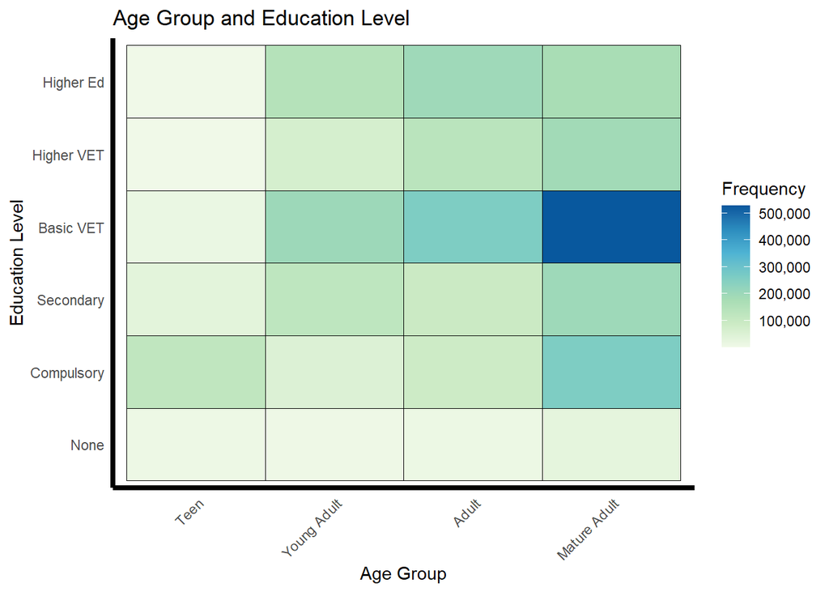

```r
heatmap_data <- education_employment_data %>%
  mutate(HIGHESTCOMPLEDU = factor(
    HIGHESTCOMPLEDU,
    levels = c("None", "Compulsory", "Secondary", "Basic VET", "Higher VET", "Higher Ed")
  )) %>%
  count(AGE_GROUP, HIGHESTCOMPLEDU)

ggplot(heatmap_data, aes(x = AGE_GROUP, y = HIGHESTCOMPLEDU, fill = n)) +
  geom_tile(color = "black") +
  scale_fill_distiller(palette = "GnBu", direction = 1,
                       labels = scales::comma) +
  labs(
    title = "Age Group and Education Level",
    x = "Age Group",
    y = "Education Level",
    fill = "Frequency"
  ) +
  theme_minimal() +
  theme(
    axis.text.x = element_text(angle = 45, hjust = 1),
    axis.line = element_line(color = "black", size = 1.5),
    panel.grid = element_blank()
  )
```

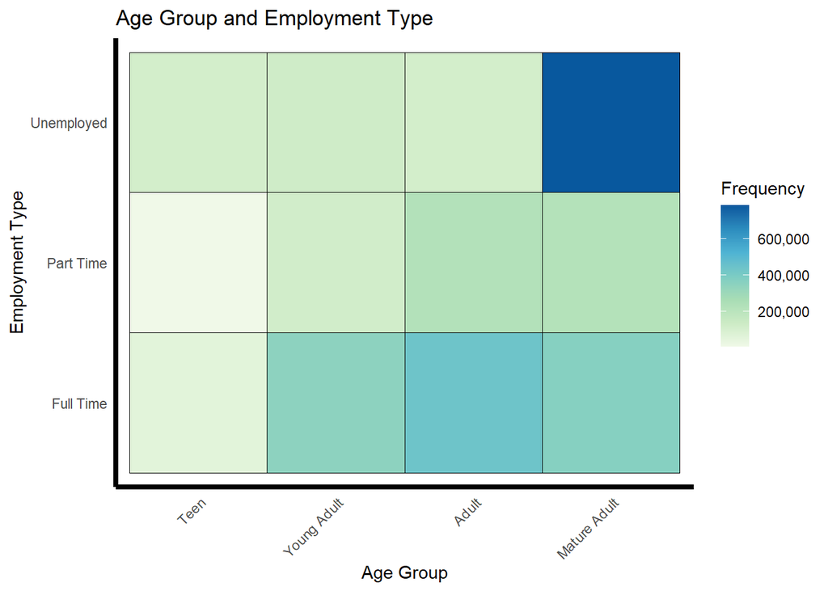

```r
heatmap_data <- education_employment_data %>%
  count(AGE_GROUP, Employment_Type)

ggplot(heatmap_data, aes(x = AGE_GROUP, y = Employment_Type, fill = n)) +
  geom_tile(color = "black") +
  scale_fill_distiller(
    palette = "GnBu",
    direction = 1,
    labels = scales::comma
  ) +
  labs(
    title = "Age Group and Employment Type",
    x = "Age Group",
    y = "Employment Type",
    fill = "Frequency"
  ) +
  theme_minimal() +
  theme(
    axis.text.x = element_text(angle = 45, hjust = 1),
    axis.line = element_line(color = "black", size = 1.5),
    panel.grid = element_blank()
  )
```

**People start to concentrate on work when they reach 30 Year Age.**

**People mostly prefer to work Full-Time**

### 2.1.2 Analyzing the people on education

**What proportion of individuals in each age group are still in education?**

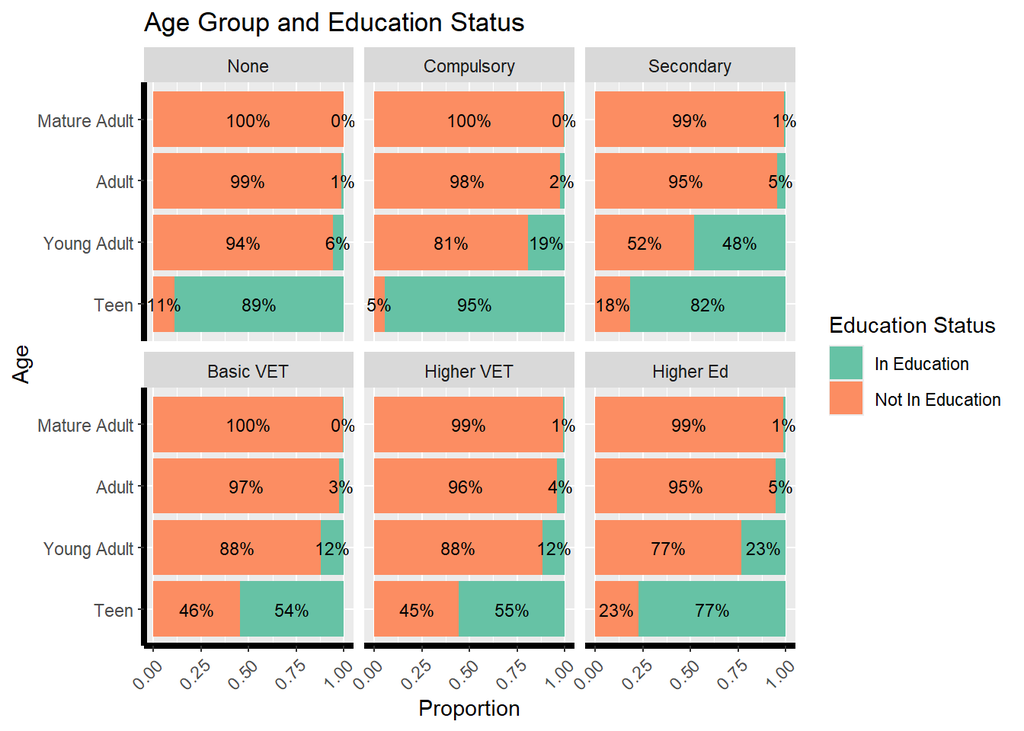

```r
data_with_proportions <- education_employment_data %>%
  group_by(HIGHESTCOMPLEDU, AGE_GROUP) %>%
  mutate(Total = n()) %>%
  mutate(HIGHESTCOMPLEDU = factor(
  HIGHESTCOMPLEDU,
  levels = c("None", "Compulsory", "Secondary", "Basic VET", "Higher VET", "Higher Ed")
  )) %>%
  group_by(HIGHESTCOMPLEDU, AGE_GROUP, IN_EDUCATION) %>%
  summarise(Count = n(), Proportion = Count / first(Total), .groups = "drop")

data_with_proportions %>%
  ggplot(aes(x = AGE_GROUP, y = Proportion, fill = IN_EDUCATION)) +
  geom_bar(stat = "identity", position = "fill") +
  geom_text(aes(label = scales::percent(Proportion, accuracy = 1)),
            position = position_fill(vjust = 0.5), size = 3) +
  theme(
    axis.text.x = element_text(angle = 45, hjust = 1),
    axis.line = element_line(size = 1.5)
  ) +
  facet_wrap(~HIGHESTCOMPLEDU) +
  scale_fill_brewer(palette = "Set2") +
  labs(
    title = "Age Group and Education Status",
    x = "Age",
    y = "Proportion",
    fill = "Education Status"
  ) +
  coord_flip()
```

**A significant portion of younger individuals are still engaged in continuing education. After the age of 30, most individuals are no longer in education, having completed their formal studies earlier in life.**

### 2.1.3 Employment and Education:

**What percentage of individuals in education are employed full-time, part-time, or unemployed?**

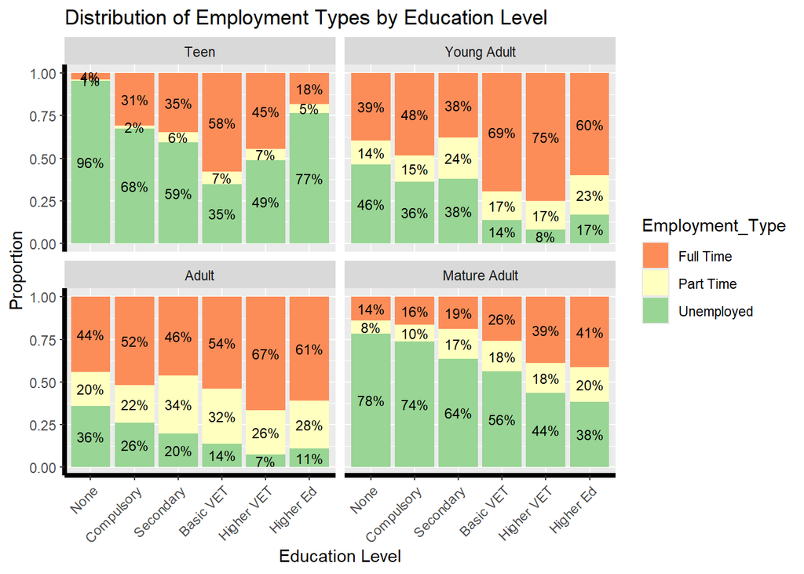

```r
data_with_proportions <- education_employment_data %>%
  group_by(AGE_GROUP, HIGHESTCOMPLEDU) %>%
  mutate(Total = n()) %>%
    mutate(HIGHESTCOMPLEDU = factor(
    HIGHESTCOMPLEDU,
    levels = c("None", "Compulsory", "Secondary", "Basic VET", "Higher VET", "Higher Ed")
  )) %>%
  group_by(AGE_GROUP, HIGHESTCOMPLEDU, Employment_Type) %>%
  summarise(Count = n(), Proportion = Count / first(Total), .groups = "drop")

ggplot(data_with_proportions, aes(x = HIGHESTCOMPLEDU, y = Proportion, fill = Employment_Type)) +
  geom_bar(stat = "identity", position = "fill") +
  geom_text(aes(label = scales::percent(Proportion, accuracy = 1)),
            position = position_fill(vjust = 0.5), size = 3) +
  facet_wrap(~AGE_GROUP) +
  theme(
    axis.text.x = element_text(angle = 45, hjust = 1),
    axis.line = element_line(size = 1.5)
  ) +
  scale_fill_brewer(palette = "Spectral") +
  labs(
    title = "Distribution of Employment Types by Education Level",
    x = "Education Level",
    y = "Proportion"
  )
```

**Higher education levels increase employment rates and reduce unemployment.**